# Transformations

## Transformations

[figure not shown]

Say you fit a linear model to data and find the residual plots look awful. One strategy to regain a valid model is to transform your data.

## Example 1: Cleaning crews

A building maintenance company is planning to submit a bid to clean corporate offices. How much should they bid? They'd like to be able to cover the job with a team of 4 crews and a team of a 16 crews, but they want to be sure. To make a good prediction, they collected data on how many crews were required over a sample of 53 days.

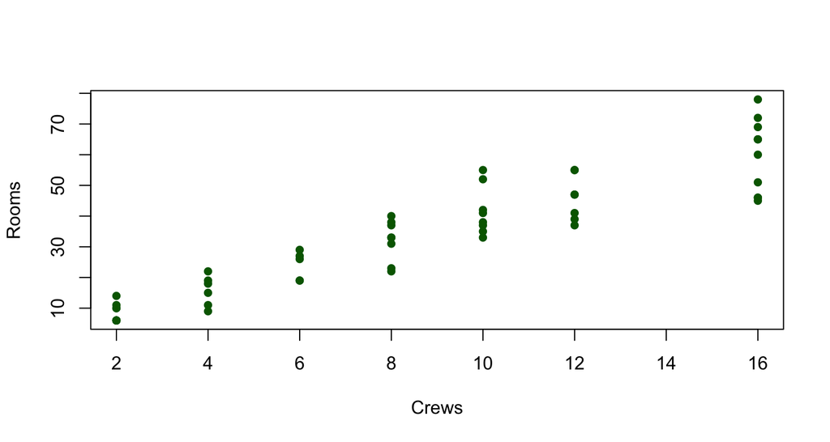

## Linear model?

```
##             Estimate Std. Error t value  Pr(>|t|)
## (Intercept)    1.785     2.0965  0.8513 3.986e-01
## Crews          3.701     0.2118 17.4721 3.554e-23
```

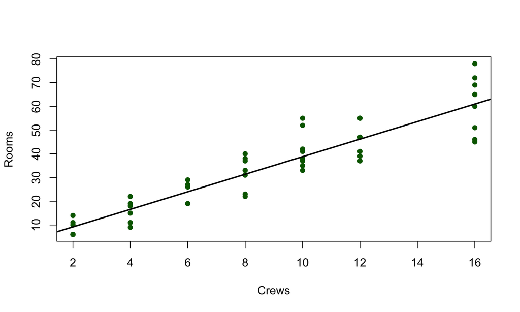

## Linearity and normality

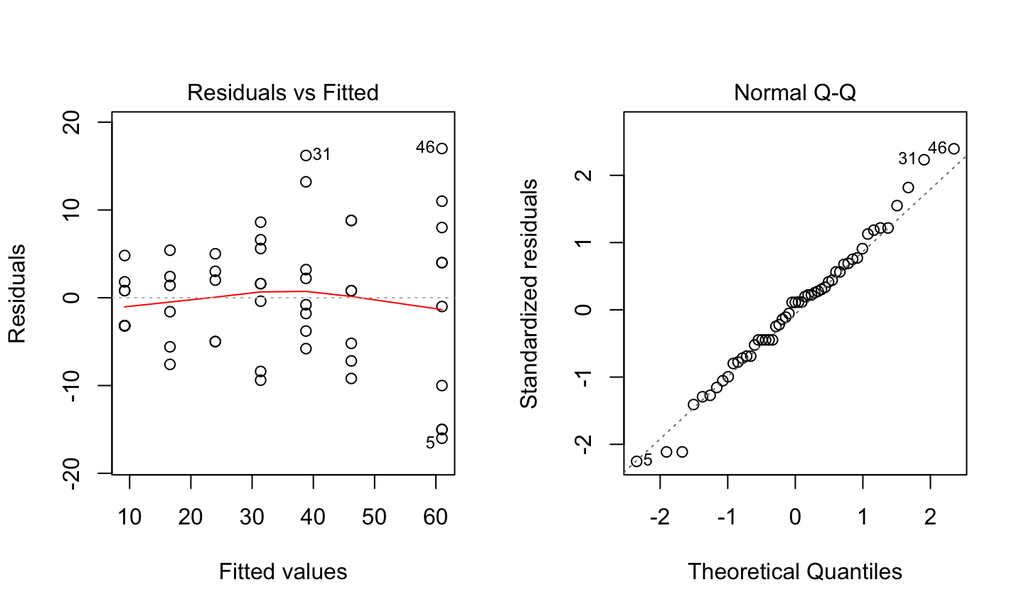

The mean function appears to be linear and the residuals are well-approximated by the normal distribution.

## Constant variance and influence

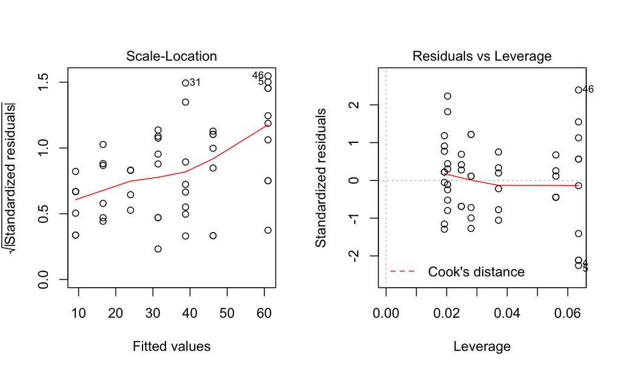

There are no influential points, however there is dramatic increasing variance.

## PIs on an invalid model

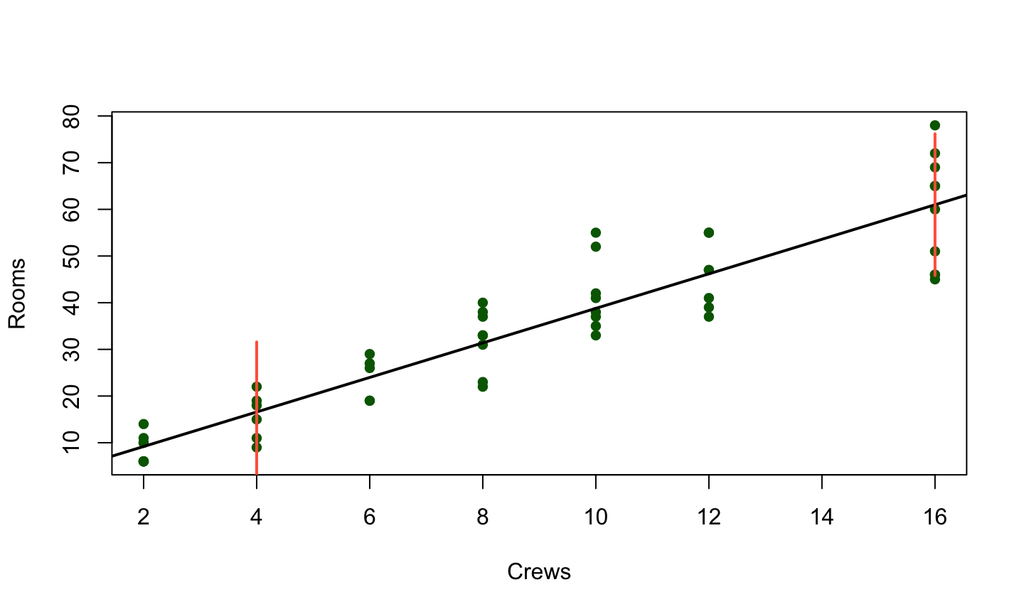

Prediction intervals are particularly sensitive to model assumptions, so we have good reason to distrust this one.

## Square root transform

The square root tranform is often useful to reducing the increasing variance that is found in many types of count data.

\[ X_t = \sqrt{X} \]

Let's transform both \(X\) and \(Y\).

```r
cleaning2 <- transform(cleaning, sqrtCrews = sqrt(Crews))
cleaning2 <- transform(cleaning2, sqrtRooms = sqrt(Rooms))
cleaning2[1:2, ]
```

```
##   Case Crews Rooms sqrtCrews sqrtRooms
## 1    1    16    51     4.000     7.141
## 2    2    10    37     3.162     6.083
```

## Transformed linear model?

```
##             Estimate Std. Error t value  Pr(>|t|)
## (Intercept)   0.2001     0.2758  0.7257 4.713e-01
## sqrtCrews     1.9016     0.0936 20.3158 4.203e-26
```

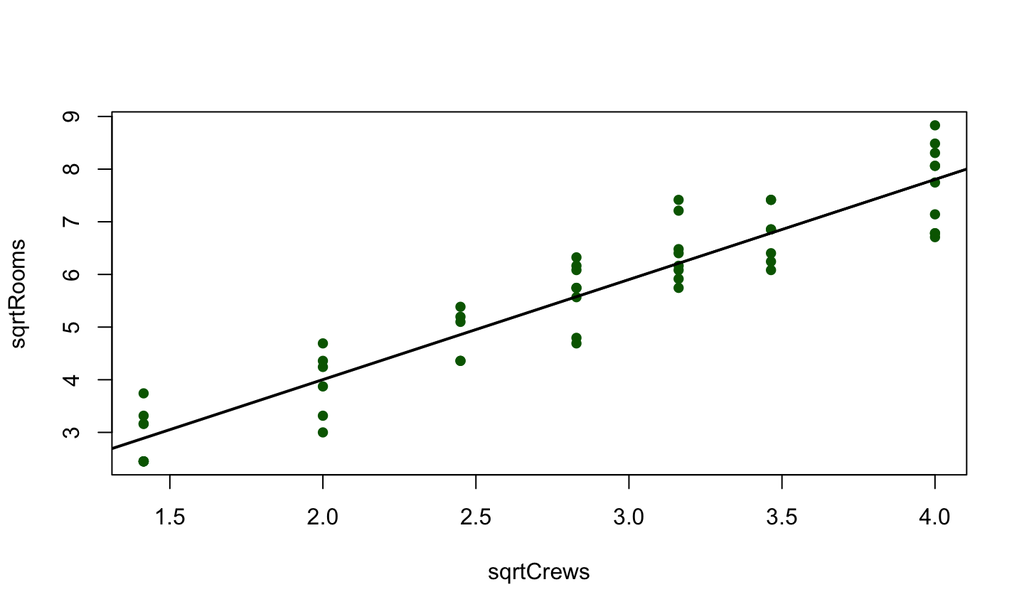

## Linearity and normality

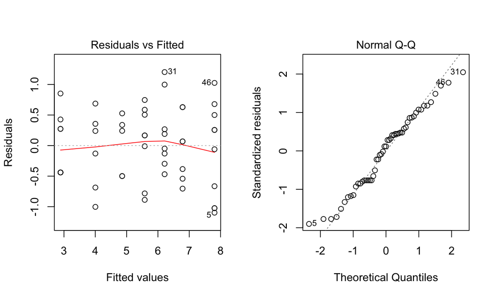

The mean function appears to be linear and the residuals are well-approximated by the normal distribution.

## Constant variance and influence

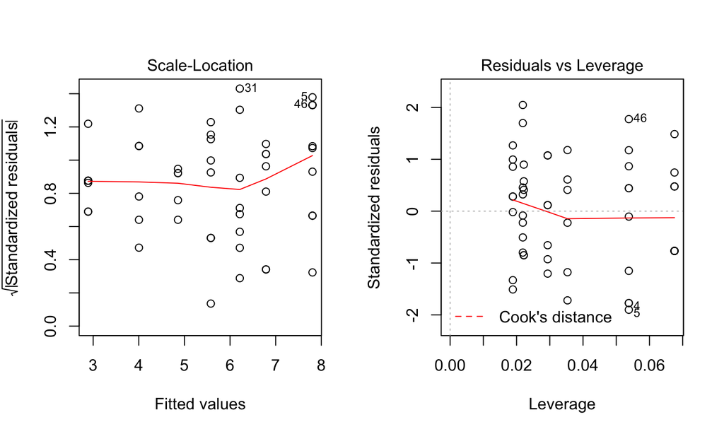

There are no influential points and the variance has been stabilized.

## PIs from a valid model

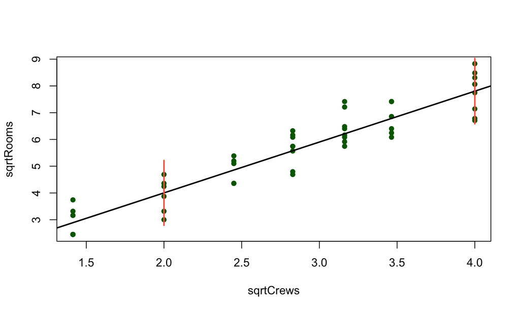

## Comparing PIs

```r
pi
```

```
##     fit    lwr   upr
## 1 16.59  1.589 31.59
## 2 61.00 45.810 76.19
```

```r
pi2^2
```

```
##     fit    lwr   upr
## 1 16.03  7.784 27.21
## 2 60.94 43.327 81.55
```

## Log Transformations

## Example 2: Truck prices

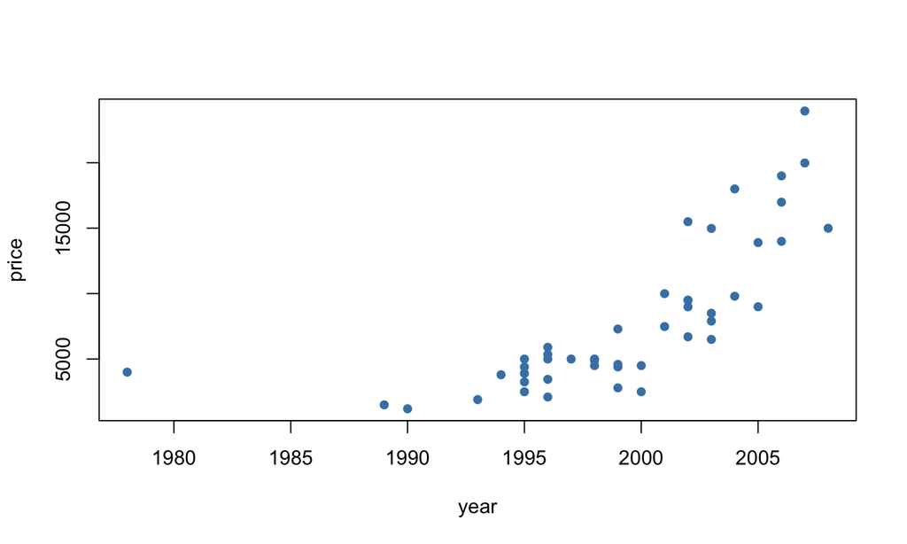

## Consider unusual observations

The very old truck will be a high leverage point and may not be of interest to model. Let's only consider trucks made in the last 20 years.

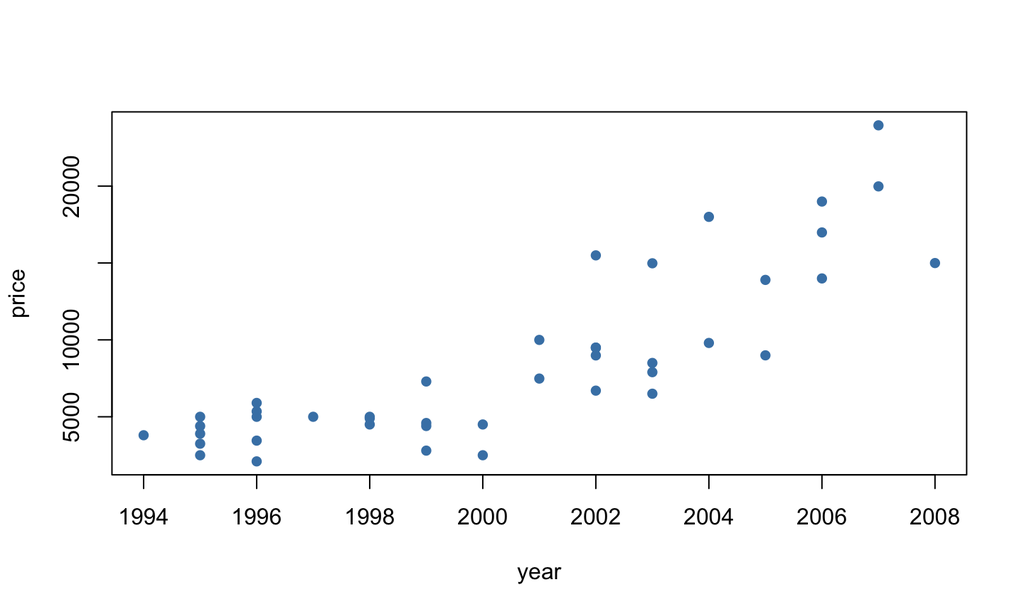

## Linear nodel?

```
##             Estimate Std. Error t value  Pr(>|t|)
## (Intercept) -2278766   238325.7  -9.562 6.924e-12
## year            1143      119.1   9.597 6.238e-12
```

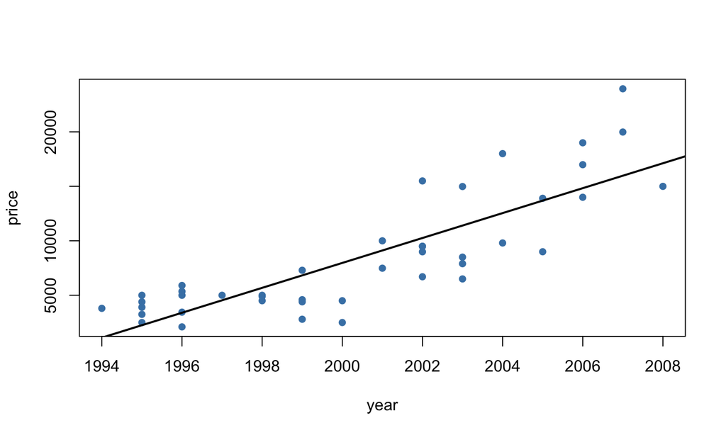

## Linearity and normality

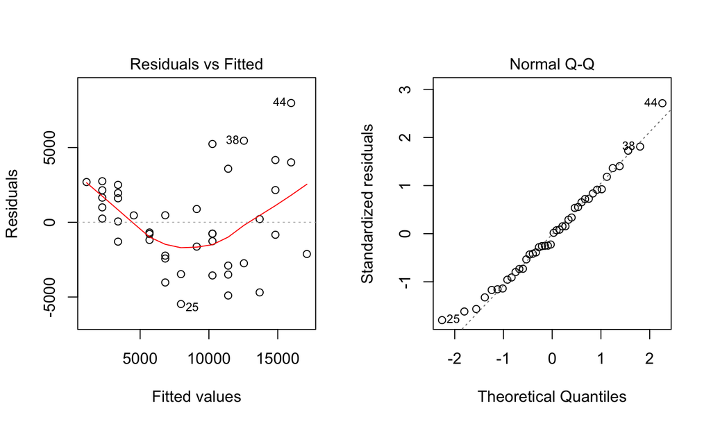

The normality assumption on the errors seems fine but there seems to be a quadratic trend in the mean function.

## Constant variance and influence

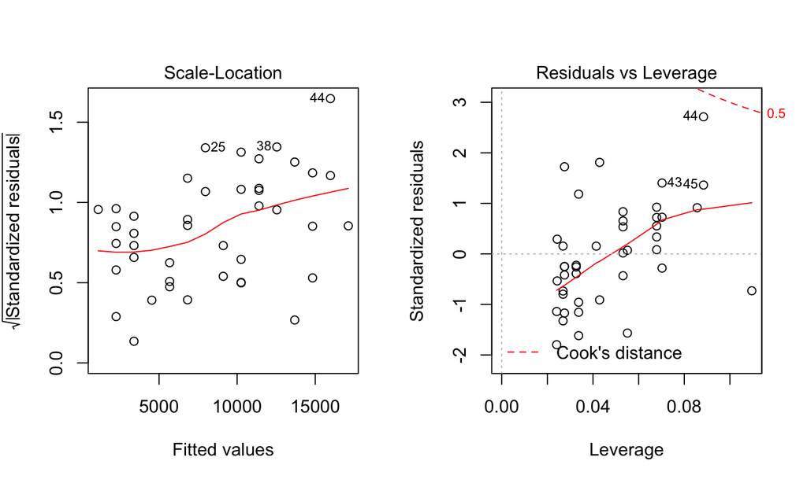

One observation (44) should be investigated for its influence. There is evidence of increasing variance in the residuals.

```r
pickups2 <- transform(pickups, log_price = log(price))
```

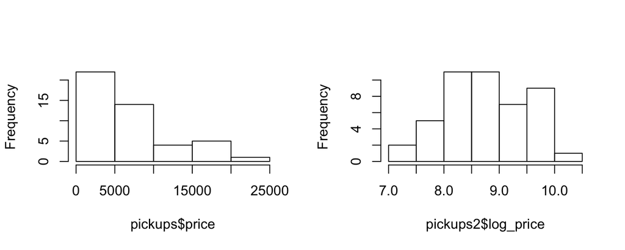

Variables that span multiple orders of magnitude often benefit from a natural log transformation.

\[ Y_t = log_e(Y) \]

## Log-transformed linear model

```
##              Estimate Std. Error t value  Pr(>|t|)
## (Intercept) -258.9981   26.12294  -9.915 2.472e-12
## year           0.1339    0.01306  10.253 9.343e-13
```

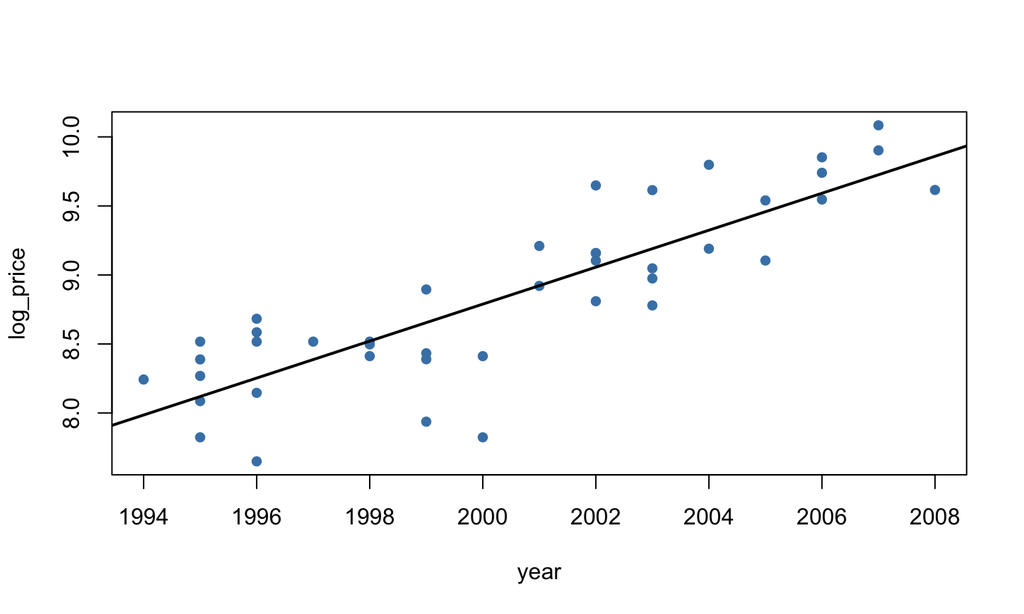

## Linearity and normality

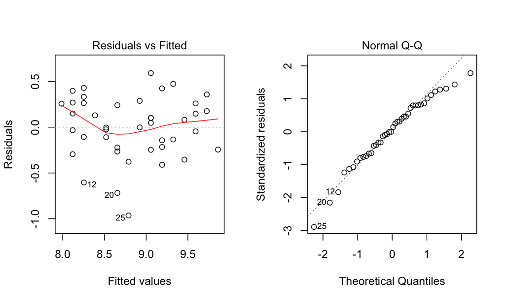

The residuals from this model appear less normal, though the quadratic trend in the mean function is now less apparent.

## Constant variance and influence

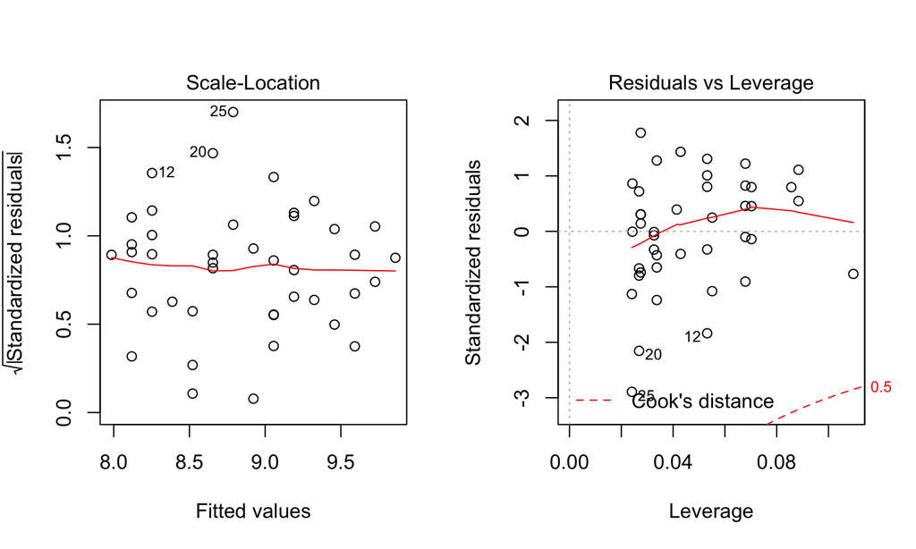

There are no points flagged as influential and our variance has been stabilized.

## Model interpretation

```
##              Estimate Std. Error t value  Pr(>|t|)
## (Intercept) -258.9981   26.12294  -9.915 2.472e-12
## year           0.1339    0.01306  10.253 9.343e-13
```

\[ \widehat{log(price)} = -258.99 + 0.13 * year \]

Which isn't very useful . . .

## Working with logs

Two useful identities:

- \[ log(a) - log(b) = log(\frac{a}{b}) \]
- \[ e^{log(x)} = x \]

The slope coefficient for the log-transformed model is 0.13, meaning the *log* price difference between cars that are one year apart is predicted to be 0.13 log dollars.

\[ \begin{eqnarray} log(price at year x + 1) - log(price at year x) &=& 0.13 \\ log(\frac{price at year x + 1}{price at year x}) &=& 0.13 \\ e^{log(\frac{price at year x + 1}{price at year x})} &=& e^{0.13} \\ \frac{price at year x + 1}{price at year x} = 1.14 \\ \end{eqnarray} \]

For each additional year the car is newer we would expect the price of the car to increase on average by a factor of 1.14.

## Transformations summary

- If a linear model fit to the raw data leads to questionable residual plots, consider transformations.
- Count data and prices often benefit from transformations.
- The natural log and the square root are the most common, but you can use any transformation you like.
- Transformations may change model interpretations.
- Non-constant variance is a serious problem but it can often be solved by transforming the response.
- Transformations can also fix non-linearity, as can polynomials - coming soon!